# multinomineq: Multinomial Models with Inequality Constraints

Daniel W. Heck

2024-02-20

[figure not shown]

The R package `multinomineq` facilitates the Bayesian analysis of discrete/categorical data using multinomial models with inequality constraints. Essentially, these types of models allow to analyze discrete choice frequencies while assuming that the corresponding choice probabilities $\theta$ are constrained by linear inequality constraints (e.g., by the simple order $\theta_{1} \leq \theta_{2}\leq \theta_{3}\leq \theta_{4}$). In the following, this vignette shows how to define and test such models in R. The second section below provides a concise formal definition of the model class.

## Example: Testing the Description-Experience Gap

The following example shows how inequality constraints can be used to test the description-experience (DE) gap in risky decision making (Hertwig et al., 2004). In the experiment, participants had to choose one of two risky gambles in each of 6 different paired comparisons (e.g., a lottery in which you win 10€ with $p=.20$ versus a lottery in which you can win 20€ with $p=.45$). The description-experience gap states that people underweigh small probabilities $p$ when making decisions based on experience. We will conduct a reanalysis of Hertwig’s data set using the inequality-constrained multinomial model in Regenwetter & Robinson (2017).

First, it is necessary to install the R package `multinomineq` from Github. Note that it is necessary to install the developer R tools first. Afterwards, `multinomineq` can be installed and loaded via:

```r
### uncomment to install packages:
# install.packages("devtools", "coda", "RcppArmadillo", "RcppProgress", "Rglpk", "quadprog")
# devtools::install_github("danheck/multinomineq")

library("multinomineq")
library("coda")
set.seed(1234)
```

### Data structure

We reanalyze the data by Hertwig et al. (2004) who collected choice frequencies of $n=25$ participants for 6 paired comparisons of risky gambles. The observed choice frequencies can simply be summarized by the frequencies of choosing “Option H” (a specific lottery, cf. original article) in each of the 6 paired comparisons:

```r
# total number of observations for each paired comparison:
n <- 25
# Frequencies of choosing "Option H" in Description condition:
HER_desc <- c(9, 16, 16, 7, 12, 16)
# Frequencies of choosing "Option H" in Experience condition:
HER_exp <- c(22, 11, 7, 14, 5, 3)
```

### Vertex ($V$-)representation

First, it is shown how to use the vertex ($V$-)representation for inequality-constrained models. Essentially, the rows of the matrix $V$ list all patterns that are predicted by a substantive theory of interest. Each prediction either states that “Option H” is chosen (value `1`) or not (value `0`). For example, if the theory makes the prediction that “Option H” is chosen only in the 4th paired comparison but otherwise not, the matrix $V$ needs to include the following pattern in one row: `c(0,0,0,1,0,0)`. Similarly, all possible predictions need to be combined to form the matrix $V$. Inequality-constrained models assume a mixture distribution over all these possible predicted patterns (e.g., due to heterogeneity across participants or trials). Geometrically, the corresponding parameter space thus represents the convex hull of the predicted patterns/vertices (i.e., all possible linear combinations of the rows of $V$ when using nonnegative weights).

For the description-experience gap, Regenwetter & Robinson (2017) used a specific decision making model (Cumulative Prospect Theory) to generate all possible predictions. The matrix $V$ lists all of these predictions when assuming that participants underweigh small probabilities $p$ of winning money. The following matrix contains all predicted patterns for the 6 risky gambles:

```r
# Underweighting of small probabilities CPT:
# (1 = choose "Option H"; 0 = do not choose "Option H")
V <- matrix(
  c(
    0, 0, 0, 0, 0, 0, # first predicted pattern
    0, 0, 0, 1, 0, 0, # second predicted pattern
    0, 0, 1, 1, 0, 0, # ...
    1, 0, 0, 0, 0, 0,
    1, 0, 0, 1, 0, 0,
    1, 0, 1, 1, 0, 0,
    1, 1, 0, 0, 0, 0,
    1, 1, 0, 0, 1, 0,
    1, 1, 0, 1, 1, 0,
    1, 1, 0, 0, 1, 1,
    1, 1, 0, 1, 0, 0,
    1, 1, 0, 1, 1, 1,
    1, 1, 1, 1, 0, 0,
    1, 1, 1, 1, 1, 0,
    1, 1, 1, 1, 1, 1
  ),
  ncol = 6, byrow = TRUE
)
```

Given this representation of the theoretical predictions, it is not easy to check whether a given vector of choice probabilities for the 6 gambles is inside the convex hull of the predicted patterns. As a remedy, one can use the function `inside()` to test this, or the function `find_inside()` to find a probability vector that is inside the convex hull of the predictions:

```r
# define a specific vector of choice probabilities:
p_observed <- c(.25, .48, .93, .10, .32, .50)

# check whether p is inside the convex hull defined by V:
inside(p_observed, V = V)
```

```
#> [1] FALSE
```

```r
# to find a (random) probability that is inside the convex hull:
find_inside(V = V, random = TRUE)
```

```
#> [1] 0.8396019 0.7133954 0.2367023 0.4547242 0.4952754 0.4340429
```

### Inequality ($Ab$-)representation

Instead of listing the vertices (or edges) of the inequality-constrained parameter space, we may instead define a set of linear inequality constraints on the parameters explicitly. For this purpose, we specify a matrix $A$ and a vector $b$. The model only allows parameter vectors $\theta$ that satisfy the inequalities defined by the matrix equation: $A \cdot \theta \leq b$.

For the description-experience gap, one can show that instead of listing the predictions by the matrix $V$ as shown above, one can equivalently describe the linear inequalities as follows:

```r
A <- matrix(
  c(
    0, 0, -1, 0, 0, 0, # first inequality
    0, 0, 0, 0, 0, -1, # second inequality
    -1, 1, 0, 0, 0, 0, # ...
    0, -1, 0, 0, 1, 0,
    0, 0, 0, 0, -1, 1,
    0, 0, 1, -1, 0, 0,
    0, 0, 0, 1, 0, 0,
    1, 0, 0, 0, 0, 0
  ),
  ncol = 6, byrow = TRUE
)

b <- c(0, 0, 0, 0, 0, 0, 1, 1)
```

For example, the third row of $A$ and the third value of $b$ specify that $-1 \cdot \theta_1 + 1 \cdot \theta_2 + 0 \cdot \theta_3+ 0 \cdot \theta_4+ 0 \cdot \theta_5+ 0 \cdot \theta_6 \leq 0$ (which is equivalent to $\theta_2 \leq \theta_1$).

Using the matrix $A$ and the vector $b$, one can use standard matrix multiplication in R (`%*%`) to check whether a given vector of choice probabilities satisfies all of the inequality constraints:

```r
p_observed <- c(.25, .48, .93, .10, .32, .50)
all(A %*% p_observed <= b)
```

```
#> [1] FALSE
```

```r
# corresponding function in multinomineq:
inside(p_observed, A, b)
```

```
#> [1] FALSE
```

```r
# find a point that satisfies the constraints:
find_inside(A, b, random = TRUE)
```

```
#> [1] 0.4849912 0.4236391 0.4196148 0.4196248 0.4236291 0.4236191
```

Note that it is sometimes possible to convert the vertex ($V$-)representation (convex hull) to the inequality ($Ab$-)representation using specific software. For older R versions (before 4.0.0), this could be done with the package `rPorta` from Github:

```r
### (not functional for R >= 4.0.0):
devtools::install_github("TasCL/rPorta")
Ab <- V_to_Ab(V)
Ab
```

### Posterior sampling

In a Bayesian framework, inequality-constrained multinomial models can be fitted by drawing posterior samples for the parameter vector of choice probabilities $\theta$. If the model is defined in terms of a matrix $V$ with predicted patterns, we obtain $M=2,000$ posterior samples as follows:

```r
# fit data from Description and Experience condition:
p_D <- sampling_binom(k = HER_desc, n = n, V = V, M = 2000, progress = FALSE)
p_E <- sampling_binom(k = HER_exp, n = n, V = V, M = 2000, progress = FALSE)
```

If the model is defined in terms of the inequality $Ab$-representation, we obtain posterior samples in a similar way by replacing the argument `V=V` by the two arguments `A=A, b=b`:

```r
# fit data from Description and Experience condition:
p_D <- sampling_binom(
  k = HER_desc, n = n, A = A, b = b,
  M = 2000, progress = FALSE
)
p_E <- sampling_binom(
  k = HER_exp, n = n, A = A, b = b,
  M = 2000, progress = FALSE
)
```

If possible, the $Ab$-representation should be used because the sampling is much more efficient than for the $V$-representation. Irrespective of how the posterior samples have been obtained, we can use standard methods in Bayesian analysis to check the convergence of the MCMC sampler and obtain summary statistics of the posterior distribution:

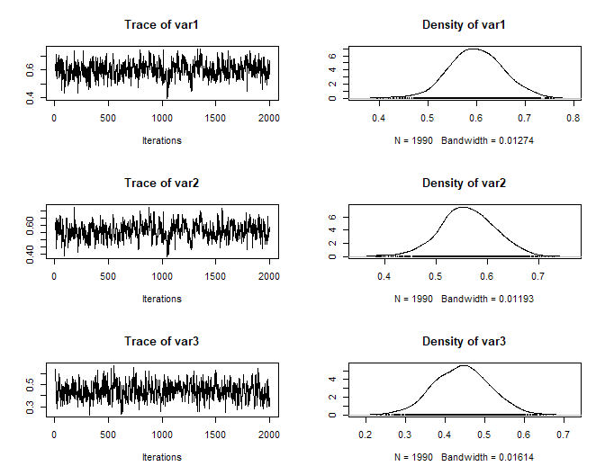

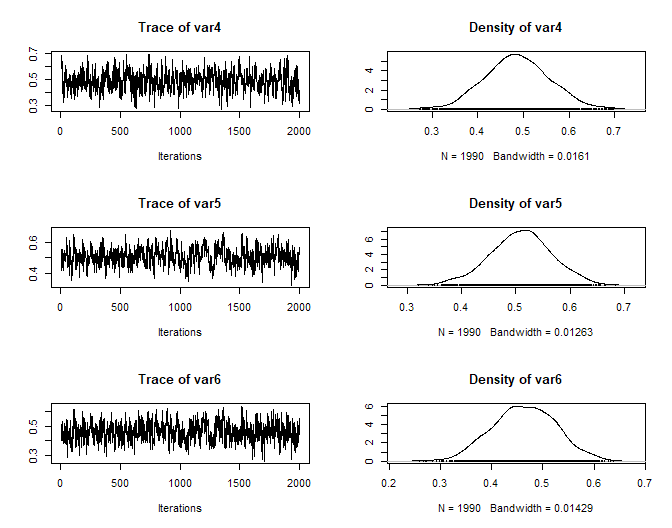

```r
# check convergence of MCMC sampler (should look like hairy caterpillars):
plot(p_D)
```

```r
# summarize posterior samples:
summary(p_D)
```

```
#>
#> Iterations = 11:2000
#> Thinning interval = 1
#> Number of chains = 1
#> Sample size per chain = 1990
#>
#> 1. Empirical mean and standard deviation for each variable,
#>    plus standard error of the mean:
#>
#>        Mean      SD Naive SE Time-series SE
#> [1,] 0.5981 0.05581 0.001251       0.003776
#> [2,] 0.5607 0.05367 0.001203       0.004074
#> [3,] 0.4417 0.06956 0.001559       0.004187
#> [4,] 0.4865 0.07051 0.001581       0.004135
#> [5,] 0.5098 0.05610 0.001258       0.003800
#> [6,] 0.4632 0.06159 0.001381       0.003376
#>
#> 2. Quantiles for each variable:
#>
#>        2.5%    25%    50%    75%  97.5%
#> var1 0.4862 0.5614 0.5977 0.6350 0.7078
#> var2 0.4490 0.5267 0.5595 0.5956 0.6657
#> var3 0.3060 0.3924 0.4422 0.4881 0.5771
#> var4 0.3552 0.4399 0.4853 0.5329 0.6282
#> var5 0.3913 0.4730 0.5114 0.5459 0.6188
#> var6 0.3453 0.4214 0.4638 0.5069 0.5832
```

Similarly, we can use posterior-predictive checks to test whether an inequality-constrained model fits the data adequately (i.e., whether the constraints hold empirically). Essentially, this method computes Pearson’s $X^2$-statistic to measure the discrepancy both for the observed and the posterior-predicted frequencies. If the model does *not* fit the data, the posterior-predicted $p$-value `ppp` will become very small (and it will be close to 0.50 if the model fits). Hence, we usually apply a criterion such as `ppp < .05` to reject models that do not fit the data, as in the following example:

```r
# posterior-predictive p-value for Description condition:
ppp_binom(prob = p_D, k = HER_desc, n = n)
```

```
#>       X2_obs      X2_pred          ppp
#> 10.287618661  3.010188404  0.004020101
```

```r
ppp_binom(prob = p_D, k = HER_exp, n = n)
```

```
#>    X2_obs   X2_pred       ppp
#> 17.687702  2.937653  0.000000
```